# Integrating RNAseq and RNAseq

Søren H Dam

Last updated on 2026-05-18

This vignette demonstrates integrating two separate scRNA-seq datasets using cyCombine. The integration is done on the SCTransformed counts.

## Dependencies

```r
library("Seurat")
library("dplyr")
library("ggplot2")
library("patchwork")
library("cyDefine") # Available at https://github.com/biosurf/cyDefine
library("cyCombine")

seed <- 942
system("mkdir -p data")
system("mkdir -p results")
```

## The datasets

### scRNA-seq - Lee

We are using the normal samples from a public COVID paper, [Lee et al., 2020](https://www.science.org/doi/10.1126/sciimmunol.abd1554)

```r
# Individual Single-Cell RNA-seq PBMC Data from Lee et al. (DOI: 10.1126/sciimmunol.abd1554)
if (!file.exists("data/lee.rds")) system("wget https://datasets.cellxgene.cziscience.com/bdee03e4-14ee-4f3e-a225-3d12f032841f.rds -O data/lee.rds")

# Load and transform Lee
lee <- readRDS("data/lee.rds")
if (! "SCT" %in% Seurat::Assays(lee)) {
  lee <- lee[, grepl("Normal", lee$sample)]
  lee <- FindVariableFeatures(lee)
  oopts <- options(future.globals.maxSize = 1.0 * 1e9)
  on.exit(options(oopts))

  lee <- Seurat::SCTransform(lee)
  lee <- FindVariableFeatures(lee)

  lee@reductions <- list()
  lee[["RNA"]] <- NULL
}
```

```
## Running SCTransform on assay: RNA
```

```
## vst.flavor='v2' set. Using model with fixed slope and excluding poisson genes.
```

```
## Calculating cell attributes from input UMI matrix: log_umi
```

```
## Variance stabilizing transformation of count matrix of size 19051 by 16298
```

```
## Model formula is y ~ log_umi
```

```
## Get Negative Binomial regression parameters per gene
```

```
## Using 2000 genes, 5000 cells
```

```
## Found 304 outliers - those will be ignored in fitting/regularization step
```

```
## Second step: Get residuals using fitted parameters for 19051 genes
```

```
## Computing corrected count matrix for 19051 genes
```

```
## Wall clock passed: Time difference of 1.075148 mins
```

```
## Determine variable features
```

```
## Centering data matrix
```

```
## Place corrected count matrix in counts slot
```

```
## Set default assay to SCT
```

```r
# Align annotation labels
lee$batch <- "lee"
# lee$sample <- "lee"
celltype <- lee$Cell.group
lee$celltype <- dplyr::case_when(
         celltype == "B cell" ~ "B cells",
         stringr::str_starts(celltype, "CD4") ~ "CD4pos",
         stringr::str_starts(celltype, "CD8") ~ "CD8pos",
         stringr::str_ends(celltype, "Monocyte") ~ "Monocytes",
         celltype == "NK cell" ~ "NK cells",
         celltype %in% c("cDC", "pDC") ~ paste0(celltype, "s"),
         lee$cell_type == "gamma-delta T cell" ~ "TCRgd",
         celltype == "Platelet" ~ "Platelets",
         TRUE ~ "Other"
         )
```

### scRNA-seq - Yoshida

```r
# https://cellxgene.cziscience.com/collections/03f821b4-87be-4ff4-b65a-b5fc00061da7
# Local and systemic responses to SARS-CoV-2 infection in children and adults
if (!file.exists("data/yoshida.rds")) system("wget https://datasets.cellxgene.cziscience.com/d911082e-b5e2-40e6-8f08-fb53c7894622.rds -O data/yoshida.rds")

# Load and transform Lee
yoshida <- readRDS("data/yoshida.rds")

if (! "SCT" %in% Seurat::Assays(yoshida)) {
  yoshida <- yoshida[, grepl("AN", yoshida$sample_id)]

  yoshida <- FindVariableFeatures(yoshida)

  oopts <- options(future.globals.maxSize = 2.0 * 1e9)
  on.exit(options(oopts))

  yoshida <- Seurat::SCTransform(yoshida)
  yoshida <- FindVariableFeatures(yoshida)

  yoshida@reductions <- list()
  yoshida[["RNA"]] <- NULL

}
```

```
## Running SCTransform on assay: RNA
```

```
## vst.flavor='v2' set. Using model with fixed slope and excluding poisson genes.
```

```
## Calculating cell attributes from input UMI matrix: log_umi
```

```
## Variance stabilizing transformation of count matrix of size 19220 by 46993
```

```
## Model formula is y ~ log_umi
```

```
## Get Negative Binomial regression parameters per gene
```

```
## Using 2000 genes, 5000 cells
```

```
## Found 665 outliers - those will be ignored in fitting/regularization step
```

```
## Second step: Get residuals using fitted parameters for 19220 genes
```

```
## Computing corrected count matrix for 19220 genes
```

```
## Wall clock passed: Time difference of 2.829858 mins
```

```
## Determine variable features
```

```
## Centering data matrix
```

```
## Place corrected count matrix in counts slot
```

```
## Set default assay to SCT
```

```r
yoshida$batch <- "yoshida"
# yoshida$sample <- "yoshida"
celltype <- yoshida$cell_type
yoshida$celltype <- dplyr::case_when(
  grepl("B cell", celltype) ~ "B cells",
  grepl("natural killer cell", celltype) ~ "NK cells",
  celltype == "conventional dendritic cell" ~ "cDCs",
  celltype == "plasmacytoid dendritic cell" ~ "pDCs",
  celltype == "gamma-delta T cell" ~ "TCRgd",
  celltype == "platelet" ~ "Platelets",
  grepl("CD4", celltype) ~ "CD4pos",
  celltype == "regulatory T cell" ~ "CD4pos",
  grepl("CD8", celltype) ~ "CD8pos",
  grepl("onocyte", celltype) ~ "Monocytes",
  TRUE ~ "Other")
```

### Merge datasets

We use the union of variable features to speed up the integration significantly. Please only use the integrated values for visualizations etc., perform your analyses and draw your conclusions based on the raw/unintegrated values.

In this vignette, we convert the Seurat object to a data.frame for compatibility with plotting and performance measures, but cyCombine can integrate the merged Seurat object directly.

```r
seu <- merge(x = lee, y = yoshida, project = "integrate_RNAseq")
# Variable features
markers <- union(VariableFeatures(lee), VariableFeatures(yoshida))
rm(lee); rm(yoshida)


# Convert to data frame
uncorrected <- seu[markers,] |>
  GetAssayData("SCT","data") |>
  t() |>
  as.data.frame() |>
  dplyr::mutate(batch = seu$batch,
                sample = seu$sample,
                celltype = seu$celltype,
                id = dplyr::row_number())
rm(seu)
# saveRDS(uncorrected, "results/02_rnaseq_rnaseq_uncorrected.RDS")
```

## Uncorrected

```r
set.seed(seed)
uncor_batch <- plot_umap(
  uncorrected,
  down_sample = T,
  sample_n = 5000,
  markers = markers,
  title = "Uncorrected",
  ref_col = "celltype")
```

```
## Generating UMAP
```

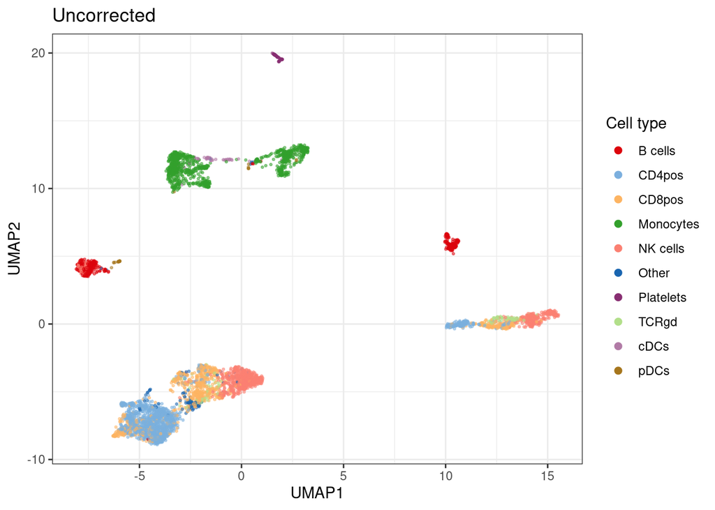

```r
# saveRDS(uncor_batch, "results/02_rnaseq_rnaseq_uncor.RDS")
# ggplot2::ggsave(plot_cell, filename = "figs/02_rnaseq_rnaseq_uncor.RDS")
uncor_batch
```

## Batch correction

For this integration, we are running two iterations of cyCombine to ensure a robust result. The first iteration uses a coarse 1x5 grid clustering, whereas the second iteration uses a somewhat fine-grained 5x5 clustering grid. Cosine distance is used with a FlowSOM clustering to emphasize the angle of variation rather than the amplitude. Note that cosine distance is not available in the default Kohonen cluster method.

```r
system.time({
  suppressMessages({ # Hide per-cluster correction info
  corrected <- cyCombine(
    uncorrected,
    markers = markers,
    cluster_method = "flowsom",
    distf = "cosine",
    seed = seed,
    method = "ComBat",
    xdim = c(1,5),
    ydim = 5,# Note: the "5" is reused in the second iteration
    mc.cores = 1
  )
  })
})
```

[output not shown]

```
##    user  system elapsed
## 557.086  85.322 434.973
```

```r
# saveRDS(corrected, "results/02_rnaseq_rnaseq_corrected.RDS")
```

## Plot results - Batch

```r
set.seed(seed)
umap_batch <- corrected |>
  group_by(sample) |>
  slice_sample(n = 5000) |>
  plot_umap(
    return_data = T,
    down_sample = F,
    seed = seed,
    metric = "cosine",
    markers = markers,
    title = "scRNA-seq Lee vs Yoshida",
    legend_title = "Dataset",
    col = "batch")
```

```
## Generating UMAP
```

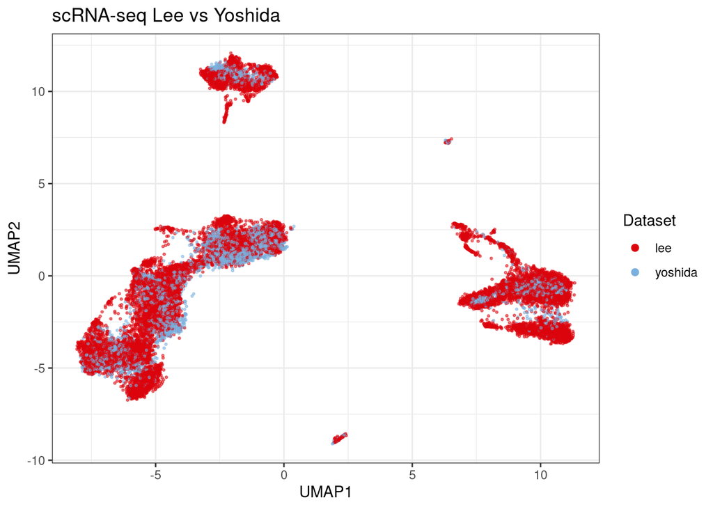

```r
# ggplot2::ggsave(umap_batch$plot, filename = "figs/02_rnaseq_rnaseq_batch.png")
# saveRDS(umap_batch$plot, "results/02_rnaseq_rnaseq_batch.RDS")
umap_batch$plot
```

## Plot results - Cells

Note: We use `plot_embedding` to reuse the UMAP coordinates from the plot above. We could also have rerun `plot_umap` for a simpler call.

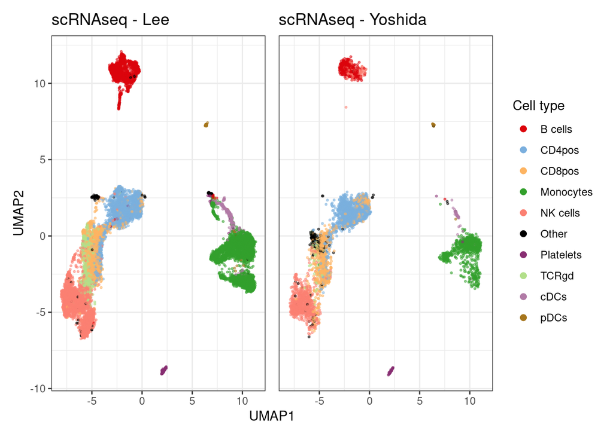

```r
celltype_colors <- cyDefine::get_distinct_colors(sort(unique(uncorrected$celltype)))
celltype_colors[["Other"]] <- "black"
set.seed(seed)

xlim <- c(min(umap_batch$data$UMAP1), max(umap_batch$data$UMAP1))
ylim <- c(min(umap_batch$data$UMAP2), max(umap_batch$data$UMAP2))

plot_cell <-
  plot_embedding(
    dplyr::filter(umap_batch$data, batch == "lee"),
    colors = celltype_colors,
    xlim = xlim,
    ylim = ylim,
    title = "scRNAseq - Lee",
    col = "celltype",
    legend_title = "Cell type") +
  plot_embedding(
    dplyr::filter(umap_batch$data, batch == "yoshida"),
    colors = celltype_colors,
    xlim = xlim,
    ylim = ylim,
    title = "scRNAseq - Yoshida",
    col = "celltype",
    legend_title = "Cell type") +
  patchwork::plot_layout(
    guides = "collect",
    axes = "collect",
    axis_titles = "collect")

# ggplot2::ggsave(plot_cell, filename = "figs/02_rnaseq_rnaseq_cell.png")
# saveRDS(plot_cell, "results/02_rnaseq_rnaseq_cell.RDS")

plot_cell
```

## Measure performance

- EMD: Reduction in Earth Movers Distance [0,1] is a metric of how much more aligned the two modalities have become
- MAD: Reduction in Median Absolute Deviation [0,1] is a metric of how much biological variance has been removed.
- CiLISI: Cell-type aware iLISI [0,1] is the global mean of the iLISIs computed for each cell type or cluster.

```r
corrected$label <- create_som(corrected, ydim = 5, xdim = 5, seed = seed, markers = markers, cluster_method = "flowsom", distf = "cosine")
```

```
## Building SOM
```

```
## Mapping data to SOM
```

```r
uncorrected$label <- corrected$label

system.time({
  lu <- cyCombine::compute_cilisi(
    uncorrected,
    markers = get_markers(uncorrected),
    label_cols = "batch",
    split_by = "label",
    return_mean = F)
})
```

```
##    user  system elapsed
##  17.366   0.389  17.824
```

```r
message("CiLISI uncorrected: ", mean(unlist(lu)))
```

```
## CiLISI uncorrected: 0.0100322993830509
```

```r
system.time({
  l <- cyCombine::compute_cilisi(
    corrected,
    markers = get_markers(corrected),
    label_cols = "batch",
    split_by = "label",
    return_mean = F)
})
```

```
##    user  system elapsed
##  19.496   0.309  19.867
```

```r
message("CiLISI corrected: ", mean(unlist(l)))
```

```
## CiLISI corrected: 0.592147820274851
```

```r
mad <- cyCombine::evaluate_mad(
  uncorrected,
  corrected,
  cell_col = "label",
  markers = markers
  )
```

```
## Computing MAD for corrected data..
```

```
## Computing MAD for uncorrected data..
```

```
## The MAD score is: 0
```

```r
emd <- cyCombine::evaluate_emd(
  uncorrected,
  corrected,
  binSize = 1,
  cell_col = "label",
  markers = markers,
  mc.cores = 39)
```

```
## Computing EMD for corrected data..
```

```
## Binning destributions using binSize 1
```

```
## Computing marker-wise EMD for each cell cluster
```

```
## Computing EMD for uncorrected data..
## Binning destributions using binSize 1
```

```
## Computing marker-wise EMD for each cell cluster
```

```
## Removing EMDs below 2 both before and after correction
```

```
## The reduction is: 0.92
```

```
## Creating plots..
```

```
## Evaluation complete.
```

```r
# saveRDS(list("emd" = emd, "mad" = mad, "CiLISI_uc" = lu, "CiLISI_c" = l), "results/02_rnaseq_rnaseq_counts_performance.RDS")
```

Contact